# Assignment 1: Reproducible Research

## Loading and preprocessing the data

1. Load the data

```r
data1 <- read.csv("activity.csv", sep = ",")
```

2. Process/transform the data (if necessary) into a format suitable for your analysis

Loading the dplyr function

```r
library(dplyr)
```

creating a new data frame tbl and also Sample data is shown by head(data2)

```r
data2 <- tbl_df(data1)

head(data2)
```

```
## Source: local data frame [6 x 3]
##
##   steps       date interval
## 1    NA 2012-10-01        0
## 2    NA 2012-10-01        5
## 3    NA 2012-10-01       10
## 4    NA 2012-10-01       15
## 5    NA 2012-10-01       20
## 6    NA 2012-10-01       25
```

## What is mean total number of steps taken per day?

1. Make a histogram of the total number of steps taken each day

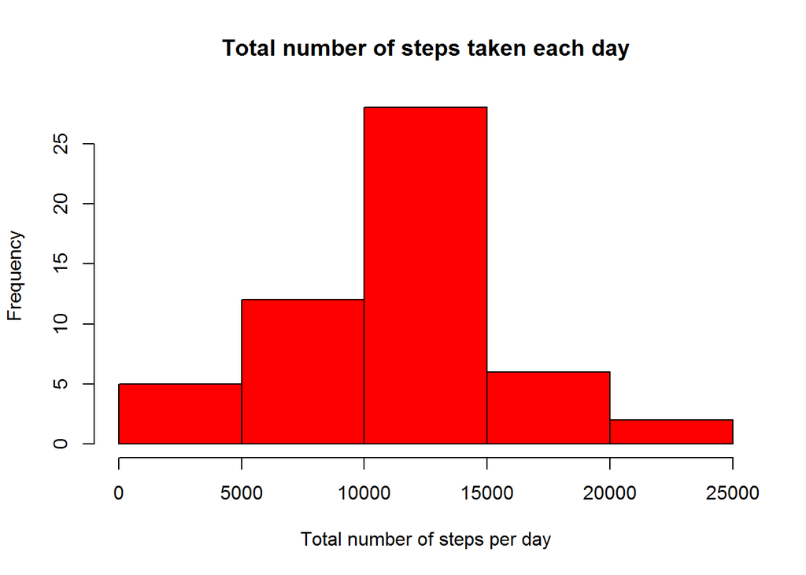

```r
totalstepsperday <- data2 %>%
        group_by(date) %>%
        summarise_each(funs(sum))

hist(totalstepsperday$steps, xlab = "Total number of steps per day", main = "Total number of steps taken each day", col="red")
```

```r
dev.print(png, file = "Plot1.png", width = 480, height = 480, units = "px")# printing the final plot with the given specifications
```

2. Calculate and report the mean and median total number of steps taken per day

```r
meanstepsperday <- data2 %>%
        group_by(date) %>% # grouped by date
        summarise(mean_steps= mean(steps))

head(meanstepsperday)
```

```
## Source: local data frame [6 x 2]
##
##         date mean_steps
## 1 2012-10-01         NA
## 2 2012-10-02     0.4375
## 3 2012-10-03    39.4167
## 4 2012-10-04    42.0694
## 5 2012-10-05    46.1597
## 6 2012-10-06    53.5417
```

```r
medianstepsperday <- data2 %>%
        group_by(date) %>% # grouped by date
        summarise(median_steps=median(steps))

head(medianstepsperday)
```

```
## Source: local data frame [6 x 2]
##
##         date median_steps
## 1 2012-10-01           NA
## 2 2012-10-02            0
## 3 2012-10-03            0
## 4 2012-10-04            0
## 5 2012-10-05            0
## 6 2012-10-06            0
```

## What is the average daily activity pattern?

Make a time series plot (i.e. type = “l”) of the 5-minute interval (x-axis) and the average number of steps taken, averaged across all days (y-axis)

Step 1. Computing the average number of steps across all days

```r
Avgstepsacrossalldays <- data2 %>%
        group_by(interval) %>% # grouped by date
        summarise(steps= mean(steps, na.rm = TRUE))
```

Step 2. plotting the average number of steps across all days

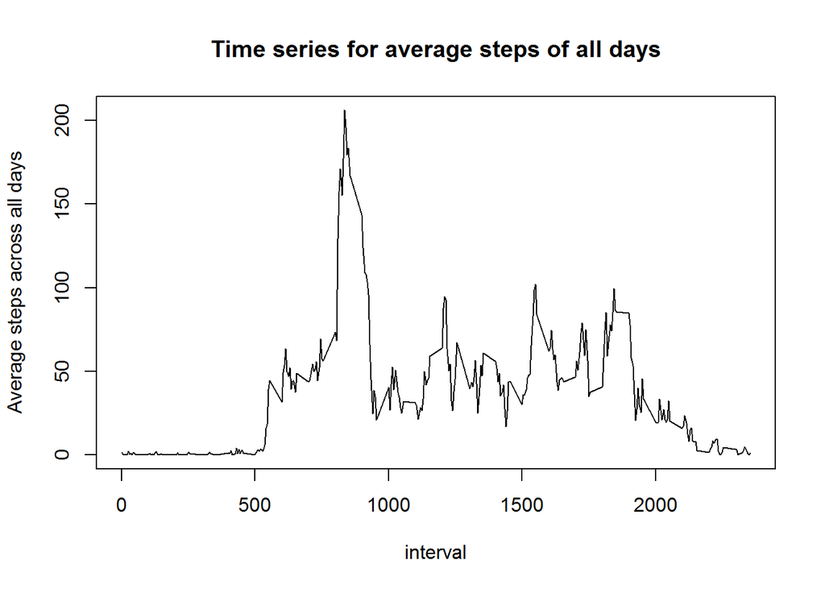

```r
plot(Avgstepsacrossalldays$interval,Avgstepsacrossalldays$steps,
     type = "l", xlab = "interval", ylab = "Average steps across all days",
     main = "Time series for average steps of all days")
```

```r
dev.print(png, file = "Plot2.png", width = 480, height = 480, units = "px")# printing the final plot with the given specifications
```

1. Which 5-minute interval, on average across all the days in the dataset, contains the maximum number of steps?

This can be done by Searching the maximum number of stepts from “Avgstepsacrossalldays” data

```r
Avgstepsacrossalldays[Avgstepsacrossalldays$steps %in% c(max(Avgstepsacrossalldays$steps)),]
```

```
## Source: local data frame [1 x 2]
##
##     interval steps
## 104      835 206.2
```

## Imputing missing values

1. Calculate and report the total number of missing values in the dataset (i.e. the total number of rows with NAs)

   Total number of missing values can be computed as:

```r
sum(is.na(data2))
```

```
## [1] 2304
```